# SFC - Wittgenstein

## Descripción del seminario

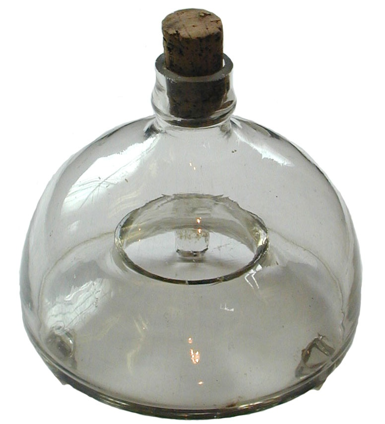

Los escritos filosóficos de Wittgenstein ejercen una fascinación especial en quien los lee con paciencia y cuidado. En este seminario, estudiaremos dos: el *Tractatus Logico-Philosophicus* y las *Investigaciones Filosóficas*.

El *Tractactus* es una investigación lógica sobre lenguaje enmarcada en la línea de Gottlob Frege y Bertrand Russell; es un texto abstracto, técnico y poco amable con el lector, pero cuya inusual mezcla de lógica, metafísica, y mística se presta para una multiplicidad de interpretaciones y énfasis.

Las *Investigaciones* es una investigación sobre el lenguaje y la mente, rica en ejemplos concretos y descriptivos, aunque quizá un tanto enmarañados y que no siempre tienen un propósito filosófico claro; es un rechazo a las posiciones del *Tractatus* y es la obra más influyente de Wittgenstein.

El estudio de estas dos obras nos ofrece la oportunidad de ver el cambio en la concepción filosófica de Wittgenstein y su particular forma de pensar y hacer filosofía. En la primera parte del seminario, estudiaremos el *Tractatus* de la mano de Tomasini (2017), quien nos ofrecerá una visión sinóptica del libro y con base en la cual podremos realizar una aproximación propia al texto. En la segunda parte del seminario, estudiaremos las *Investigaciones* enfocándonos en pasajes particulares de la obra, buscando entender conceptos centrales como “juego del lenguaje”, “regla” y “representación perspicua”.

**Profesor**: Juan Camilo Espejo-Serna  
**Horario y salón**: Martes, 10:00am - 1:00pm. Atelier 103

**Página web del seminario**: https://jcunisabana.github.io/Witt/

## Objetivos

- Leer críticamente, analizar e interpretar la propuesta filosófica temprana de Ludwig Wittgenstein.
- Leer críticamente, analizar e interpretar la propuesta filosófica tardía de Ludwig Wittgenstein.
- Planear y elaborar textos interpretativos y argumentativos con base en las teorías de Ludwig Wittgenstein.
- Utilizar TIC para apoyar el estudio filosófico de la obra de Ludwig Wittgenstein

## Metodología

#### **Antes de la sesión**

- Quienes estén a cargo de la presentación oral deberán preparar una exposición de 20-25 minutos de duración. Deben consultar **siempre** con el profesor (¡antes de la sesión!) y ponerse de acuerdo en una estrucutra para la presentación.
- Todos los estudiantes deberán subir un control de lectura por tarde **75 horas** antes de la sesión.

#### **Durante la sesión**

- Quienes esten a cargo de la presentación oral deberán realizar su exposición. Pueden, por ejemplo, escribir un texto para ser leído, o preparar diapositivas para guiar su exposición o utilizar el tablero como apoyo. Es su decisión pero deben tener en cuenta que el objetivo es lograr presentar y explicar el texto correspondiente.
- Todos deben atender con cuidado a la exposición y formular preguntas al respecto. Revisen si entienden la exposición y si están de acuerdo; pregunten por las relaciones con los temas anteriormente expuestos.

## Plan semanal

### Martes 22 Enero

**Semana 1**

Vida y obra de Ludwig Wittgenstein.  
Presentación del programa y las reglas de juego del seminario.

*Actividades*

Presentación a cargo del profesor: las introducciones del TLP y las IF.  
Taller de filosofía por recortes.  
Taller sobre el programa.

*Para la próxima*

Leer **todo** el *Tractatus Logico-Philosophicus*.

### Martes 29 Enero

**Semana 2**

La multiplicidad de interpretaciones del *TLP*.

*Actividades*

Taller sobre el orden del TLP. Presentación a cargo del profesor.

*Para la próxima*

Leer Tomasini, Cap 2 y Tomasini, Cap 3.  
Control de lectura.

### Martes 05 Febrero

**Semana 3**

Ontología y lógica

*Actividades*

Presentación de Tomasini, Cap 2 a cargo de (Por definir).  
Presentación de Tomasini, Cap 3 a cargo de (Por definir).

*Para la próxima*

Leer Tomasini, Cap 4 y Tomasini, Cap 5.  
Control de lectura.

### Martes 12 Febrero

**Semana 4**

Lógica, matemáticas y ciencia

*Actividades*

Presentación de Tomasini, Cap 4 a cargo de (Por definir).  
Presentación de Tomasini, Cap 5 a cargo de (Por definir).

*Para la próxima*

Leer Tomasini, Cap 6 y Tomasini, Cap 7.  
Control de lectura.

### Martes 19 Febrero

**Semana 5**

Solipsismo, misticismo y filosofía

*Actividades*

*Para la próxima*

Segunda versión del taller de filosofía por recortes.

### Martes 26 Febrero

**Semana 6**

Interpretaciones propias del *TLP*

*Actividades*

Auto-evaluación y co-evaluación del taller de recortes.

*Para la próxima*

Leer IF Parte I, §§1-88.  
Control de lectura

### Martes 05 Marzo

**Semana 7**

Crítica a la definición ostensiva

*Actividades*

Presentación de IF Parte I, §§1-88 a cargo de Derly y Laura

*Para la próxima*

Leer IF Parte I, §§ 89-133.  
Control de lectura

### Martes 12 Marzo

**Semana 8**

La noción de filosofía

*Actividades*

Presentación de IF Parte I, §§ 89-133 a cargo de Nicolás.

*Para la próxima*

Leer IF Parte I, §§ 134 - 242.  
Control de lectura

### Martes 19 Marzo

**Semana 9**

Seguimiento de reglas

*Actividades*

Presentación de IF Parte I, §§ 134 - 242 a cargo de Daniela.

*Para la próxima*

Leer IF Parte I, §§ 243 - 275.  
Control de lectura

### Martes 26 Marzo

**Semana 10**

Lenguaje privado

*Actividades*

Presentación de IF Parte I, §§ 243 - 275 a cargo de Esteban.

*Para la próxima*

Leer IF Parte I, §§276 - 307.  
Control de lectura

### Martes 02 Abril

**Semana 11**

Lo interno y lo externo.

*Actividades*

Presentación de IF Parte I, §§276 - 307 a cargo de Katherin.

*Para la próxima*

Leer IF Parte II, 11.  
Control de lectura

### Martes 09 Abril

**Semana 12**

Ver y ver como

*Actividades*

Presentación de IF Parte II, 11 a cargo de Santiago.

*Para la próxima*

Escribir **dos páginas** en respuesta a alguna de las preguntas pre-establecidas.

### Martes 16 Abril

**Semana 13**

NO HAY SESIÓN (Semana Santa)

*Actividades*

–

*Para la próxima*

Leer (Comentarista).  
Control de lectura

### Martes 23 Abril

**Semana 14**

(Por definir)

*Actividades*

Presentación de (Comentarista) a cargo de (Por definir).

*Para la próxima*

Leer (Comentarista).  
Control de lectura

### Martes 30 Abril

**Semana 15**

(Por definir)

*Actividades*

Presentación de (Comentarista) a cargo de (Por definir).

*Para la próxima*

Leer (Comentarista).  
Control de lectura

### Martes 07 Mayo

**Semana 16**

(Por definir)

*Actividades*

Presentación de (Comentarista) a cargo de (Por definir).

*Para la próxima*

Leer (Comentarista).  
Control de lectura

### Martes 14 Mayo

**Semana 17**

(Por definir)

*Actividades*

Presentación de (Comentarista) a cargo de (Por definir).

*Para la próxima*

Revisión final del ensayo final.

### Martes 21 Mayo

**Semana 18**

*Actividades*

Entrega de ensayo final

## Evaluación

#### **Talleres**

Actividades para realizar en casa y en clase que servirán de pasos intermedios en el aprendizaje. En clase se ofrecerán instrucciones más precisas cuando llegue el momento de cada taller.

#### **Presentación oral**

Extensión: entre 20 y 25 minutos.

La presentación debe 1) tener una reseña crítica del texto asignado y 2) ofrecer puntos para la discusión. Ustedes son los encargados de la sesión durante el tiempo asignado; es su deber coordinar la dinámica durante ese tiempo.

#### **Control de lectura**

Extensión: entre 400 y 1000 palabras.

Para cada lectura asignada, los estudiantes deben escribir un texto corto con la tesis principal, tres afirmaciones/presuposiciones del texto y tres preguntas/desafíos al texto.

Los controles deberán ser subidos a la plataforma virtual a más tardar **75 horas** antes de la sesión. Todos los estudiantes empiezan con 5.0 en esta nota; por cada vez que no se participe dentro del rango de tiempo especificado, la nota será disminuida de acuerdo con los siguientes parámetros: primera vez: -0.5; segunda vez: -1.0; tercera vez: -1.5; cuarta vez: -2.0.

Todos tienen un control de lectura “de gracia”. Es decir, pueden dejar de entregar uno sin problema; el primer control de lectura que les falte no cuenta. Por ejemplo, si no entregan el control de lectura de la sesión en la que tienen que hacer la presentación y entregan todos los demás, su nota igual queda en 5.0.

#### **Ensayo argumentativo**

Extensión: entre 2000 y 3500 palabras.

Un texto argumentativo de en donde se responda a una pregunta. Se debe hacer uso de literatura secundaria de acuerdo con las normas de citación. En clase se ofrecerán las instrucciones más precisas cuando llegue el momento.

#### **Calificación**

| Actividad | % | Corte |
| --- | --- | --- |
| Taller sobre el programa | 3% | 1 |
| Presentación oral | 6% | 1 |
| Taller filosofía por recortes | 3% | 1 |
| Taller orden | 3% | 1 |
| Controles de lectura | 15% | 1 |
| Controles de lectura | 15% | 2 |
| Presentación oral | 15% | 2 |
| Primer borrador ensayo final | 8% | 3 |
| Controles de lectura | 8% | 3 |
| Ensayo final | 24% | 3 |

**Toda** entrega tarde injustificada verá la nota disminuida en 0.5 unidades por cada día tarde. No haber entregado antes de la hora acordada equivale a entregar un día tarde.